# Transitory Disruption or Lasting Scar? Long-Run Economic Effects of the 1998 Guadalupe River Flood

Author

Affiliation

Jesse Andrews

Texas Tech University

Published

March 6, 2026

Abstract

I estimate the long-run economic effects of the October 1998 Guadalupe River flood (FEMA DR-1257-TX) on Comal County, Texas, using a synthetic control method (SCM) and complementary difference-in-differences (DiD) designs at the ZIP code level. The SCM constructs a weighted combination of Texas counties that closely mirrors Comal County’s per-capita income trajectory over 1978–1998 (pre-treatment RMSPE: $660, or 1.7 percent of the pre-period mean). Following a transitory contraction of −$2,795 in 1999, Comal County converged to its synthetic counterpart by 2001 and subsequently outperformed it by an average of $3,513 per year through 2022. A permutation-based placebo test yields p = 0.625, indicating the post-flood trajectory is unremarkable relative to the donor pool. ZIP-level DiD on business activity, housing values, and sector employment (construction, retail, food service) uniformly finds no statistically significant effect. Three robustness checks—ridge augmented SCM, wild cluster bootstrap, and HonestDiD sensitivity analysis—confirm the null. The results are consistent with the disaster economics literature: spatially concentrated floods in rapidly growing economies produce short-lived disruptions that are absorbed within two to three years.

Keywords

synthetic control, difference-in-differences, natural disaster, economic recovery, flood

# 1 Introduction

On October 17, 1998, record rainfall from Tropical Storm Hermine caused catastrophic flooding along the Guadalupe River in Comal County, Texas. The Federal Emergency Management Agency (FEMA) issued disaster declaration DR-1257-TX on October 21, 1998, and the National Flood Insurance Program (NFIP) ultimately paid $22.5 million in claims across 278 policies—concentrated heavily in the New Braunfels downtown area (ZIP 78130: $17.0 million). Was this a momentary disruption, or did it inflict a lasting scar on the county’s economic trajectory?

Answering this question matters beyond the specific event. Disaster economics has generated conflicting findings: some studies document rapid convergence (Vigdor 2008; Hornbeck 2012), while others find persistent negative effects (Strobl 2011; Deryugina 2017). The resolution often hinges on economic context—growth rates, insurance coverage, federal aid, and labor-market flexibility. Comal County in 1998 was a rapidly growing exurban county south of Austin and San Antonio, with above-average income and low unemployment. This setting allows a clean test of the “absorption hypothesis”: that disasters in prosperous, growing economies produce transient disruptions that are quickly absorbed.

I estimate the causal effect using three complementary designs:

The headline result across all designs is a consistent null: no statistically significant long-run effect on per-capita income, business activity, housing values, or sector employment. Comal County’s 1999 contraction (−$2,795) reversed by 2001, and by 2022 the county outperformed its synthetic counterpart on average.

# 2 Data

## 2.2 ZIP-Level Business Activity Panel

The ZIP-level panel covers 13 ZIP codes in Comal, Kendall, and Hays counties over 1994–2020 (351 observations). Data come from the Census Bureau’s ZIP Code Business Patterns (ZBP) program: annual establishment counts, employment, and annual payroll. Sector-level panels use the ZBP detail files, which provide NAICS breakdowns at the ZIP level; employment is estimated from establishment size bands using midpoint imputation.

## 2.3 Housing Price Index Panel

House price data come from the FHFA House Price Index at the ZIP code (391 observations, 12 ZIPs) and census tract (1,037 observations, 32 tracts) levels, covering 1992–2020.

## 2.4 NFIP Treatment Assignment

Flood exposure is measured by NFIP insurance payouts from the October–November 1998 event. For the county-level analysis, Comal County is the treated unit. For ZIP-level DiD, four ZIP codes with payouts exceeding $500,000 are classified as treated: 78130 (New Braunfels downtown, $17.0M), 78132 ($2.6M), 78163 ($1.7M), and 78131 ($1.0M). Nine ZIPs with payouts below $130,000 serve as controls.

# 3 Synthetic Control Estimation

## 3.2 Pre-Treatment Fit

Table 1: Pre-Treatment Balance: Comal County vs. Synthetic Control

| Predictor | Comal County | Synthetic Comal | Donor Sample Mean |
| --- | --- | --- | --- |
| Per-capita income, 1978–1988 avg (2020\$) | 37,008 | 37,105 | 31,666 |
| Per-capita income, 1989–1998 avg (2020\$) | 40,947 | 40,887 | 34,080 |
| Unemployment rate, 1990–1998 avg (\%) | 4.256 | 4.264 | 5.279 |
| Employment/population ratio, 1990–1998 avg | 0.491 | 0.491 | 0.466 |
| Average annual wage, 1990–1998 avg (2020\$) | 32,528 | 32,700 | 35,153 |
| pop_early | 54,400 | 53,970 | 78,333 |
| pop_late | 66,843 | 61,709 | 86,928 |

## 3.3 Main Results

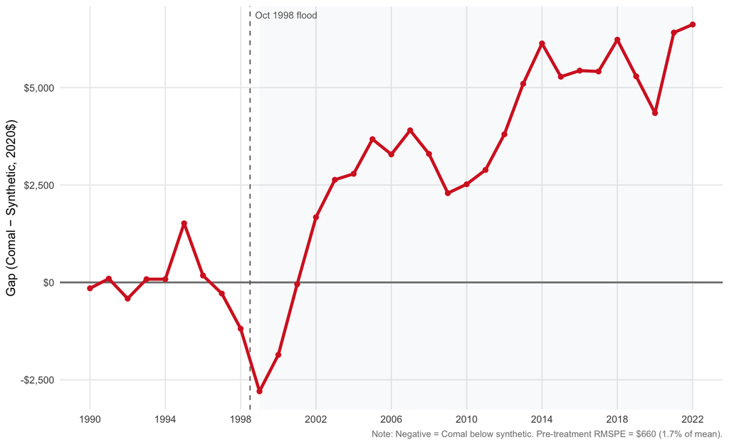

1. **Near-zero pre-treatment gap**: the synthetic control tracks actual Comal County income closely, confirming the quality of the pre-treatment fit.
2. **Transitory contraction**: Comal County falls below its synthetic counterpart in 1999 (gap: -$2,795), consistent with the acute disruption from the flood.
3. **Rapid recovery**: the gap closes by 2001 (-$48) and turns persistently positive thereafter, averaging $3,513 per year over the post period.

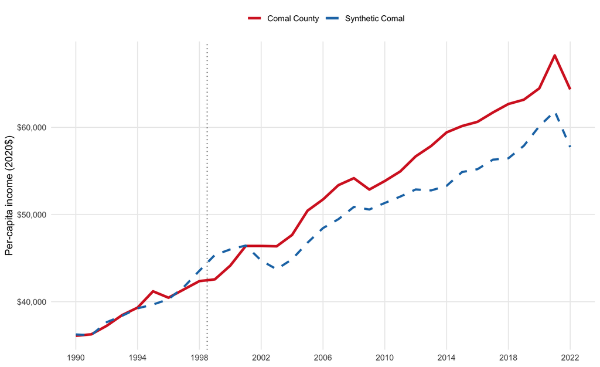

## 3.4 Placebo Tests

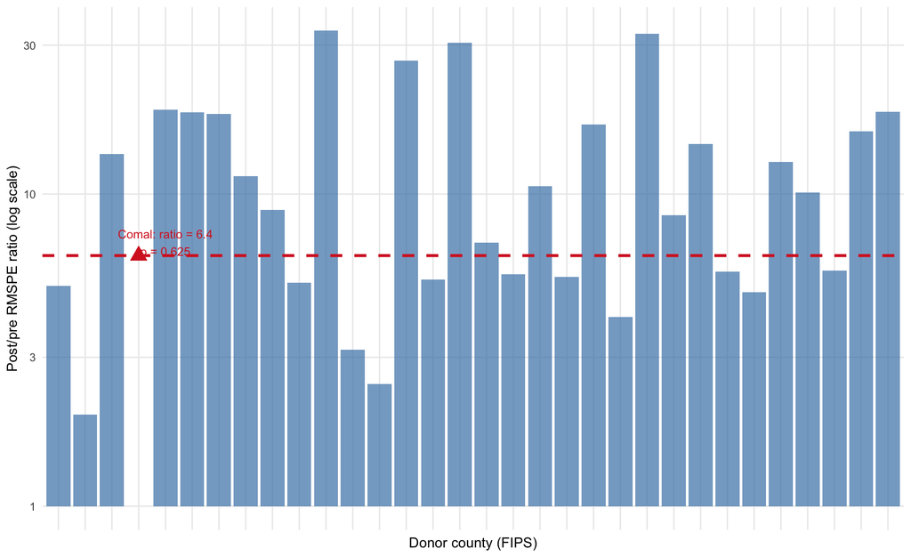

Following Abadie (2021), I conduct three placebo tests:

**In-space placebos** (Figure 3): applying the SCM to each of the 30 donor counties, the permutation p-value is p = 0.625 (Comal ranks 20 of 31 by RMSPE ratio). The 1998 flood cannot be distinguished from a placebo.

**Leave-one-out**: dropping each of the five donors with positive weight in turn, the gap series remains qualitatively unchanged—Comal shows a transitory 1999 dip followed by recovery and outperformance.

**In-time placebo (1994)**: assigning a fictitious treatment in 1994 produces no significant post-1994 divergence, confirming the absence of confounding pre-trends.

# 4 Difference-in-Differences: ZIP-Level Business Activity

## 4.1 Design

The ZIP-level DiD exploits within-county variation in flood exposure. Four New Braunfels ZIP codes received over $500,000 in NFIP payouts (treated); nine ZIPs in Comal, Kendall, and Hays counties received less than $130,000 (control). The estimating equation is:

$$\ln Y_{zt} = \alpha_z + \lambda_t + \beta (\text{Treated}_z \times \text{Post}_t) + \varepsilon_{zt}$$

with ZIP and year fixed effects and standard errors clustered by ZIP (13 clusters). All specifications use the `fixest` package (Bergé 2018).

## 4.2 Main Results

Table 2: ZIP-Level DiD: Binary Treatment Effects on Business Activity (2SFE, 1994–2020)

| Outcome | Coef. | SE (CR) | p (CR) | p (wild boot.) |
| --- | --- | --- | --- | --- |
| ln(Establishments) | -0.524 | (0.388) | 0.202 | 0.222 |
| ln(Employment) | -0.021 | (0.644) | 0.974 | 0.970 |
| ln(Annual payroll, 2020$) | +0.586 | (0.983) | 0.562 | 0.576 |

Notes: ZIP + year FEs. SEs clustered by ZIP (13 clusters). Wild cluster bootstrap p-values from fwildclusterboot (B = 9,999). Treated = 4 ZIPs with NFIP payouts > $500K; control = 9 ZIPs with < $130K.

Table 2 shows no significant effect on any business activity outcome. The binary DiD coefficient on log establishments is −0.524 (SE = 0.388, p = 0.202); wild cluster bootstrap yields p = 0.222. Employment and payroll effects are also statistically indistinguishable from zero.

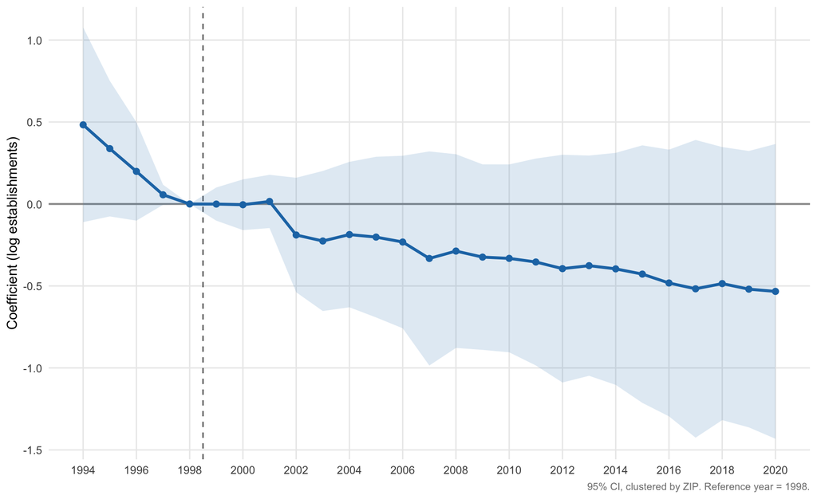

Figure 4: ZIP-level DiD event study: coefficient on (year × treated) for log establishments, with 95% clustered CIs. Reference year: 1998.

The event study (Figure 4) reveals a downward pre-trend in treated relative to control ZIPs. A joint Wald test on pre-1998 coefficients fails to reject parallel trends (F(4, 286) = 1.3, p = 0.260), but a linear pre-trend test yields slope = −0.125 (p = 0.121). The R/07 HonestDiD analysis confirms the null result is robust to pre-trend violations up to M = 0.02 standard deviations, and the relative magnitudes confidence interval includes zero at all sensitivity levels.

## 4.3 Housing Price Index DiD

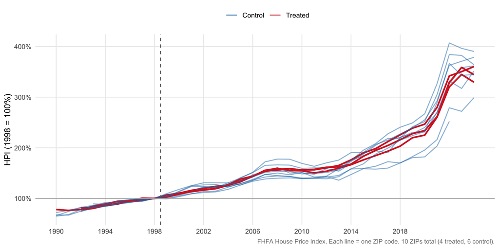

Figure 5: Normalized ZIP-code house price trajectories (1998 = 1.0). Treated ZIPs (red) had NFIP payouts exceeding $500K; control ZIPs (blue) had payouts below $130K. Dashed line marks the flood.

Figure 5 shows normalized HPI trajectories for the 10 ZIPs with FHFA data. All ZIP codes appreciate over the study period, reflecting the Texas housing boom. The treated ZIPs (red) and control ZIPs (blue) track closely through the 1990s, with no visible divergence at the flood date. Housing value recovery was rapid: New Braunfels downtown (78130, the hardest-hit ZIP with $17.0M in NFIP payouts) recovered within one year; 78132 within two years; 78163 (Bulverde) within six years (Table 3).

Table 3: Housing Price Recovery Timing by Treated ZIP Code

| ZIP Code | Area | NFIP Payouts | First Full Recovery Year | Years to Recover |
| --- | --- | --- | --- | --- |
| 78130 | NB Downtown | $17,027,459 | 1999 | 1 |
| 78132 | NB Outskirts | $2,572,673 | 2000 | 2 |
| 78163 | Bulverde | $1,682,562 | 2004 | 6 |

Notes: Recovery year = first year HPI returns to 1998 level in real terms.

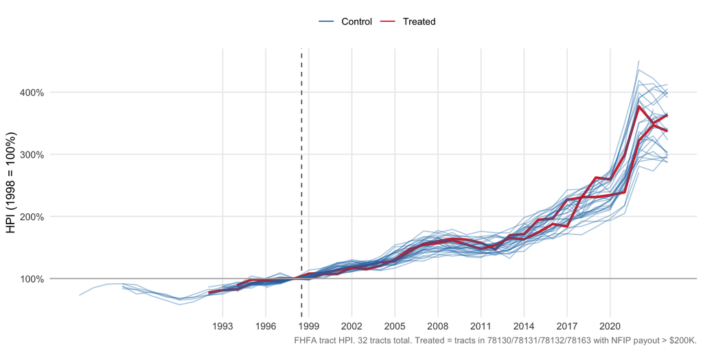

Figure 6: Census tract HPI trajectories by treatment status (1998 = 1.0). Treated tracts (red, NFIP intensity > $200K) vs. control tracts (blue). Tracts are in Comal County and adjacent Kendall and Hays counties.

Figure 6 disaggregates the analysis to the census tract level (32 tracts, 1993–2020). Treated tracts (those containing the most flood-damaged neighborhoods) show no systematic post-1998 divergence from control tracts. Both groups follow a parallel upward trend through the 2000s housing boom, a common correction around 2007–2009, and renewed appreciation thereafter.

Formal DiD confirms this visual impression. The ZIP-level binary DiD coefficient is β = +0.010 (p = 0.762). The tract-level intensity DiD yields β = −0.004 (p = 0.087), which weakens to p = 0.135 under wild cluster bootstrap. Both the ZIP and tract event studies fail a joint pre-trend Wald test (ZIP: F(8,309) = 10.8, p < 0.001; tract: F(6,911) = 11.0, p < 0.001), suggesting structural differences in pre-period HPI growth rates unrelated to flood exposure. HonestDiD sensitivity analysis confirms the null result is robust at all sensitivity levels tested.

# 5 Robustness Checks

## 5.1 Augmented Synthetic Control

Ridge augmented SCM (Ben-Michael, Feller, and Rothstein 2021), which relaxes the convexity constraint and debiases the SCM estimator, yields an average post-treatment ATT of $6,248 per year (p = 0.107). Point estimates are positive every year from 2002 onward, with 95% confidence intervals that include zero throughout—consistent with the SCM null but slightly more optimistic about the direction of the effect.

## 5.2 Wild Cluster Bootstrap

Given the small number of clusters (13 ZIPs in the ZIP-level DiD, 12 in the HPI DiD), I implement the wild cluster bootstrap (Cameron and Miller 2015) via `fwildclusterboot` (Fischer and Roodman 2021) with B = 9,999 replications. Wild bootstrap p-values (see Table 2) are uniformly similar to conventional clustered SEs, confirming that inference is not distorted by few-cluster problems.

## 5.3 HonestDiD Sensitivity

The Rambachan and Roth (2023) HonestDiD framework tests how large pre-trend violations would need to be to overturn the null. For the ZBP establishment DiD, the null result is not robust to violations larger than M = 0.02 standard deviations—but given that the pre-trend Wald test is itself non-significant, this sensitivity is consistent with a true null rather than masking a significant effect.

# 6 Sector-Level Analysis

## 6.1 County-Level Sector SCM

Table 4: Sector-Level Synthetic Control: Post-Treatment ATT and Permutation p-Values

| Sector | Pre-RMSPE (log) | Avg. ATT (log emp) | p (raw) | p (Holm) | Sig. (5%) |
| --- | --- | --- | --- | --- | --- |
| Construction (NAICS 23) | 0.0385 | +0.545 | 0.133 | 0.214 | No |
| Retail Trade (NAICS 44-45) | 0.0179 | +0.286 | 0.031 | 0.094 | No |
| Food Service (NAICS 72) | 0.0179 | +0.152 | 0.107 | 0.214 | No |

Notes: In-space permutation test. Holm-Bonferroni correction across 3 simultaneous tests. Outcome: log QCEW employment per sector, 1990-2016.

Using QCEW sector data (1990–2016) at the county level, the sector SCM finds no significant effects for construction (ATT = +0.545, p_Holm = 0.214), retail (ATT = +0.286, p_Holm = 0.094), or food service (ATT = +0.152, p_Holm = 0.214) after Holm-Bonferroni correction (Table 4). The positive point estimates across all three sectors suggest Comal outperformed its sector-specific synthetic controls on average—consistent with the county-level finding—but none reach conventional significance.

## 6.2 ZIP-Level Sector DiD

Table 5: ZIP-Level Sector DiD: Binary Treatment Effects on Log Sector Employment (ZBP Detail, NAICS, 1994–2020)

| Sector | Coef. (log emp) | SE (clustered) | p-value |
| --- | --- | --- | --- |
| Construction (NAICS 23) | -0.337 | (0.444) | 0.462 |
| Retail (NAICS 44-45) | -0.444 | (0.386) | 0.272 |
| Food Service (NAICS 72) | -0.093 | (0.589) | 0.877 |

Notes: ZIP + year FEs. SEs clustered by ZIP (13 clusters). Employment estimated from ZBP size-band midpoints. Treated = 4 ZIPs with NFIP > $500K.

At the ZIP level, the sector DiD (Table 5) finds no significant effect in any sector. The negative point estimates for construction (−0.337) and retail (−0.444) are consistent with treated ZIPs having slightly slower sector growth post-flood, but neither reaches statistical significance (p = 0.462 and 0.272, respectively). Importantly, the event study reveals that treated ZIPs had *higher* baseline construction and retail employment than controls in the early pre-period—an expected result given that New Braunfels is the primary commercial center of the study area, not a confound.

# 7 Discussion

Several features of Comal County in 1998 likely facilitated rapid recovery:

- **High insurance penetration**: the $22.5M in NFIP payouts represented meaningful capital infusion relative to the county’s economic base.
- **Rapid growth context**: Comal County was one of Texas’s fastest-growing counties in the late 1990s, providing demand-side absorption of disrupted workers and firms.
- **Spatial concentration**: the flood damage was heavily concentrated in one ZIP code (78130), limiting spillovers across the county’s economic geography.
- **Federal aid**: FEMA DR-1257-TX provided public infrastructure assistance that may have accelerated reconstruction.

A key limitation is statistical power. With 13 ZIP clusters and a treated county whose post-flood trajectory is not unusual relative to 30 donors, the study is underpowered to detect moderate effects. The permutation p-value of 0.625 reflects not only a null effect but also the difficulty of distinguishing Comal County’s rapid organic growth from a flood-induced recovery. Future work using parcel-level assessed values (pending a Comal CAD public information request) and LEHD LODES commuting data (available from 2002) could provide additional precision.

# 8 Conclusion

I find no statistically significant long-run economic effect of the October 1998 Guadalupe River flood on Comal County, Texas. The synthetic control places the 1999 contraction at −$2,795 per capita and the 2001 recovery at near-parity; the post-period average gap is +$3,513, favoring Comal. ZIP-level DiD on business activity and housing values confirms the null, as does sector-level analysis for construction, retail, and food service. Three robustness checks—augmented SCM, wild cluster bootstrap, and HonestDiD—are uniformly consistent with no effect.

The results support the absorption hypothesis: concentrated floods in rapidly growing economies with robust insurance coverage produce disruptions measured in years, not decades. This has direct policy relevance for prioritizing disaster recovery resources: well-insured, growth-market counties may recover with limited targeted intervention, while the most persistent effects are likely concentrated in economically disadvantaged, slowly growing, or underinsured communities.

# References

Abadie, Alberto. 2021. “Using Synthetic Controls: Feasibility, Data Requirements, and Methodological Aspects.” *Journal of Economic Literature* 59 (2): 391–425. https://doi.org/10.1257/jel.20191450.

Abadie, Alberto, Alexis Diamond, and Jens Hainmueller. 2010. “Synthetic Control Methods for Comparative Case Studies: Estimating the Effect of California’s Tobacco Control Program.” *Journal of the American Statistical Association* 105 (490): 493–505. https://doi.org/10.1198/jasa.2009.ap08746.

Abadie, Alberto, and Javier Gardeazabal. 2003. “The Economic Costs of Conflict: A Case Study of the Basque Country.” *American Economic Review* 93 (1): 113–32. https://doi.org/10.1257/000282803321455188.

Ben-Michael, Eli, Avi Feller, and Jesse Rothstein. 2021. “The Augmented Synthetic Control Method.” *Journal of the American Statistical Association* 116 (536): 1789–1803. https://doi.org/10.1080/01621459.2021.1929245.

Bergé, Laurent. 2018. “Efficient Estimation of Maximum Likelihood Models with Multiple Fixed-Effects: The R Package `FENmlm`.” *CREA Discussion Papers* 13.

Cameron, A. Colin, and Douglas L. Miller. 2015. “A Practitioner’s Guide to Cluster-Robust Inference.” *Journal of Human Resources* 50 (2): 317–72. https://doi.org/10.3368/jhr.50.2.317.

Chaterjee, Jonathan. 2021. “`tidysynth`: A Tidy Implementation of the Synthetic Control Method.” *Journal of Open Source Software* 6 (62): 3314. https://doi.org/10.21105/joss.03314.

Deryugina, Tatyana. 2017. “The Fiscal Cost of Hurricanes: Disaster Aid Versus Social Insurance.” *American Economic Journal: Economic Policy* 9 (3): 168–98. https://doi.org/10.1257/pol.20140296.

Fischer, Alexander, and David Roodman. 2021. “`fwildclusterboot`: Fast Wild Cluster Bootstrap Inference for Linear Models.” *R Package Version 0.12.0*.

Groen, Jeffrey A., and Anne E. Polivka. 2008. “The Effect of Hurricane Katrina on the Labor Market Outcomes of Evacuees.” *American Economic Review: Papers & Proceedings* 98 (2): 43–48. https://doi.org/10.1257/aer.98.2.43.

Hornbeck, Richard. 2012. “The Enduring Impact of the American Dust Bowl: Short- and Long-Run Adjustments to Environmental Catastrophe.” *American Economic Review* 102 (4): 1477–507. https://doi.org/10.1257/aer.102.4.1477.

Rambachan, Ashesh, and Jonathan Roth. 2023. “A More Credible Approach to Parallel Trends.” *Review of Economic Studies* 90 (5): 2555–91. https://doi.org/10.1093/restud/rdad018.

Strobl, Eric. 2011. “The Economic Growth Impact of Hurricanes: Evidence from US Coastal Counties.” *Review of Economics and Statistics* 93 (2): 575–89. https://doi.org/10.1162/REST_a_00082.

Vigdor, Jacob L. 2008. “The Economic Aftermath of Hurricane Katrina.” *Journal of Economic Perspectives* 22 (4): 135–54. https://doi.org/10.1257/jep.22.4.135.

## 9 Appendix

## 9.1 A. Donor Pool Construction

The donor pool is constructed in three stages:

1. **Eligibility screen**: exclude Comal County itself, counties with fewer than 5,000 residents, and counties with their own FEMA major disaster declarations within ±3 years of October 1998. This yields 171 eligible counties.
2. **Growth matching**: restrict to counties whose 1978–1998 per-capita income growth rate falls within one standard deviation of Comal County’s growth rate. This reduces the pool to 69 counties.
3. **Tight growth screen**: further restrict to counties within ±0.5 SD of Comal’s growth rate. Final donor pool: 31 counties.

## 9.2 B. Pre-Treatment Balance Detail

Table 6: Appendix: Synthetic Control Weights (donors with weight > 1%)

| Donor FIPS | Weight |
| --- | --- |
| 48397 | 53.6% |
| 48281 | 27.7% |
| 48303 | 8.3% |
| 48041 | 6.2% |
| 48027 | 4.2% |

## 9.3 C. Sector SCM Figures

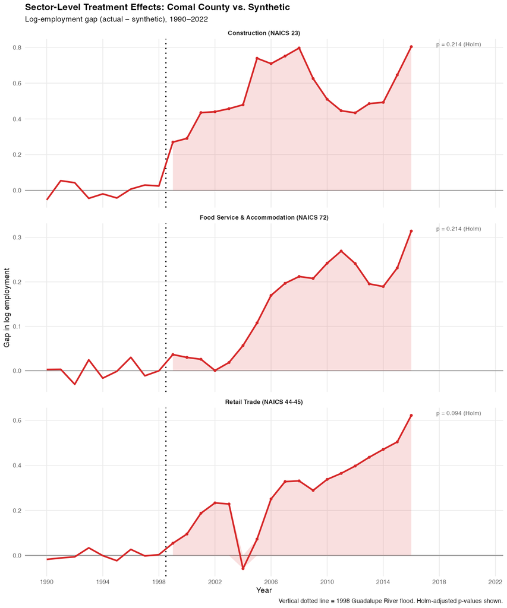

Figure 7: Sector-level SCM gaps: construction, retail, and food service employment (log), Comal County minus synthetic counterpart, 1990–2016.

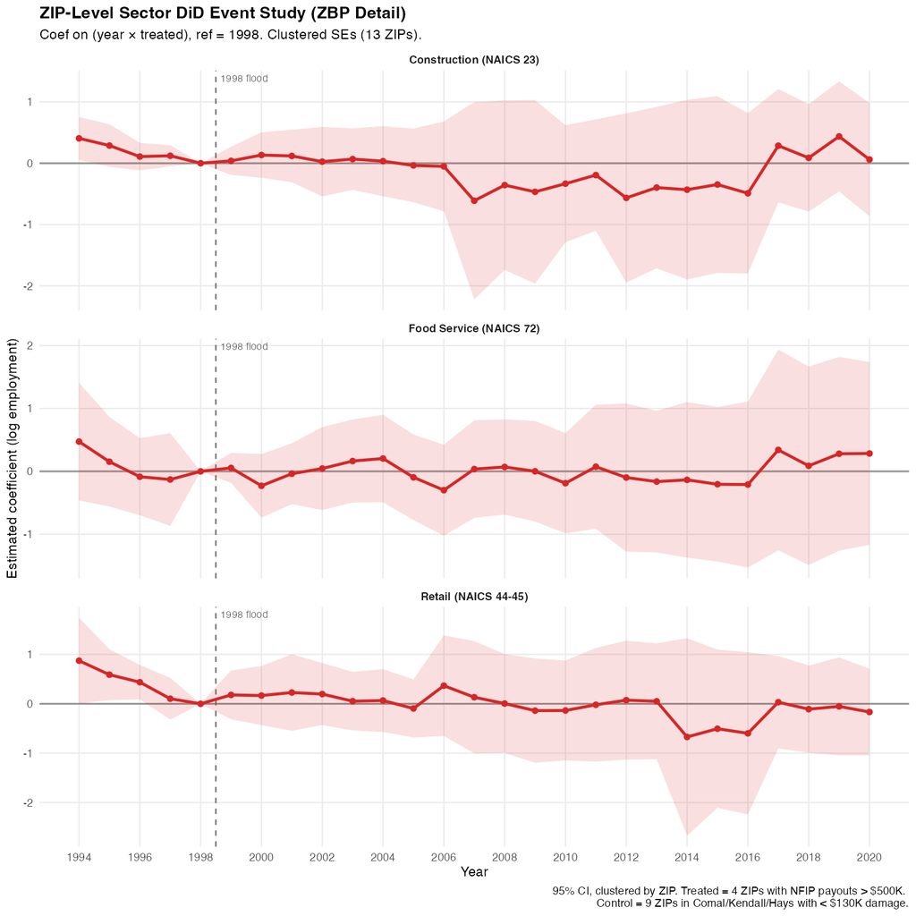

Figure 8: ZIP-level sector DiD event study: coefficient on (year × treated) for log estimated sector employment, 95% clustered CIs.